# Above_Median Project

Tabitha Hagen

2022-10-15

# Project for BAN 502 Predictive Analytics

# Read in the clean_ames_table which was created in “THagenBAN502Project_Phase1.rmd”

```r
ames_df <- readRDS("new_ames_table.rds")
```

```r
str (ames_df)
```

```
## tibble [2,053 × 22] (S3: tbl_df/tbl/data.frame)
##  $ Above_Median   : Factor w/ 2 levels "Yes","No": 1 2 1 1 1 1 1 1 1 1 ...
##  $ Lot_Shape      : Factor w/ 4 levels "Slightly_Irregular",..: 1 2 1 2 1 1 1 1 1 2 ...
##  $ Overall_Qual   : Factor w/ 10 levels "Above_Average",..: 1 2 1 3 2 1 4 4 1 3 ...
##  $ Mas_Vnr_Type   : Factor w/ 5 levels "Stone","None",..: 1 2 3 2 2 3 2 2 2 2 ...
##  $ Exter_Qual     : Factor w/ 4 levels "Typical","Good",..: 1 1 1 2 1 1 2 2 1 1 ...
##  $ Foundation     : Factor w/ 6 levels "CBlock","PConc",..: 1 1 1 1 2 2 2 2 2 2 ...
##  $ Bsmt_Qual      : Factor w/ 6 levels "Typical","Good",..: 1 1 1 1 2 1 2 2 2 2 ...
##  $ Heating_QC     : Factor w/ 5 levels "Fair","Typical",..: 1 2 2 3 4 3 3 3 3 4 ...
##  $ Kitchen_Qual   : Factor w/ 5 levels "Typical","Good",..: 1 1 2 3 1 2 2 2 1 2 ...
##  $ Fireplace_Qu   : Factor w/ 6 levels "Good","No_Fireplace",..: 1 2 2 3 3 1 2 3 2 4 ...
##  $ Garage_Type    : Factor w/ 7 levels "Attchd","BuiltIn",..: 1 1 1 1 1 1 1 1 1 1 ...
##  $ Garage_Finish  : Factor w/ 4 levels "Fin","Unf","RFn",..: 1 2 2 1 1 1 3 3 1 2 ...
##  $ Mas_Vnr_Area   : num [1:2053] 112 0 108 0 0 20 0 0 0 0 ...
##  $ Second_Flr_SF  : num [1:2053] 0 0 0 0 701 678 0 0 0 0 ...
##  $ Low_Qual_Fin_SF: num [1:2053] 0 0 0 0 0 0 0 0 0 0 ...
##  $ Half_Bath      : num [1:2053] 0 0 1 1 1 1 0 0 0 1 ...
##  $ Fireplaces     : num [1:2053] 2 0 0 2 1 1 0 1 0 1 ...
##  $ Wood_Deck_SF   : num [1:2053] 210 140 393 0 212 360 0 237 483 192 ...
##  $ Open_Porch_SF  : num [1:2053] 62 0 36 0 34 36 82 152 21 0 ...
##  $ Enclosed_Porch : num [1:2053] 0 0 0 0 0 0 0 0 0 0 ...
##  $ Screen_Porch   : num [1:2053] 0 120 0 0 0 0 144 0 0 0 ...
##  $ Neighborhood   : Factor w/ 28 levels "North_Ames","Gilbert",..: 1 1 1 1 2 2 3 3 2 2 ...
```

```r
summary(ames_df)
```

```
##  Above_Median                Lot_Shape           Overall_Qual  Mas_Vnr_Type
##  Yes:1043     Slightly_Irregular  : 714   Average      :587   Stone  : 166
##  No :1010     Regular             :1275   Above_Average:518   None   :1231
##               Moderately_Irregular:  53   Good         :411   BrkFace: 638
##               Irregular           :  11   Very_Good    :237   BrkCmn :  17
##                                           Below_Average:169   CBlock :   1
##                                           Excellent    : 70
##                                           (Other)      : 61
##      Exter_Qual    Foundation        Bsmt_Qual       Heating_QC
##  Typical  :1272   CBlock:880   Typical    :911   Fair     :  61
##  Good     : 682   PConc :911   Good       :849   Typical  : 618
##  Excellent:  78   Wood  :  4   Excellent  :178   Excellent:1040
##  Fair     :  21   BrkTil:216   No_Basement: 57   Good     : 333
##                   Slab  : 36   Fair       : 57   Poor     :   1
##                   Stone :  6   Poor       :  1
##
##     Kitchen_Qual        Fireplace_Qu              Garage_Type     Garage_Finish
##  Typical  :1070   Good        :538   Attchd             :1204   Fin      :509
##  Good     : 790   No_Fireplace:993   BuiltIn            : 127   Unf      :872
##  Excellent: 142   Typical     :409   Basment            :  29   RFn      :563
##  Fair     :  50   Poor        : 36   Detchd             : 549   No_Garage:109
##  Poor     :   1   Excellent   : 21   No_Garage          : 108
##                   Fair        : 56   CarPort            :  15
##                                      More_Than_Two_Types:  21
##   Mas_Vnr_Area    Second_Flr_SF    Low_Qual_Fin_SF      Half_Bath
##  Min.   :   0.0   Min.   :   0.0   Min.   :   0.000   Min.   :0.0000
##  1st Qu.:   0.0   1st Qu.:   0.0   1st Qu.:   0.000   1st Qu.:0.0000
##  Median :   0.0   Median :   0.0   Median :   0.000   Median :0.0000
##  Mean   : 103.8   Mean   : 326.1   Mean   :   4.973   Mean   :0.3751
##  3rd Qu.: 164.0   3rd Qu.: 701.0   3rd Qu.:   0.000   3rd Qu.:1.0000
##  Max.   :1600.0   Max.   :1862.0   Max.   :1064.000   Max.   :2.0000
##
##    Fireplaces     Wood_Deck_SF     Open_Porch_SF    Enclosed_Porch
##  Min.   :0.000   Min.   :   0.00   Min.   :  0.00   Min.   :  0.00
##  1st Qu.:0.000   1st Qu.:   0.00   1st Qu.:  0.00   1st Qu.:  0.00
##  Median :1.000   Median :   0.00   Median : 27.00   Median :  0.00
##  Mean   :0.603   Mean   :  93.52   Mean   : 48.17   Mean   : 23.02
##  3rd Qu.:1.000   3rd Qu.: 168.00   3rd Qu.: 72.00   3rd Qu.:  0.00
##  Max.   :4.000   Max.   :1424.00   Max.   :742.00   Max.   :584.00
##
##   Screen_Porch           Neighborhood
##  Min.   :  0.00   North_Ames   : 327
##  1st Qu.:  0.00   College_Creek: 183
##  Median :  0.00   Old_Town     : 181
##  Mean   : 16.68   Edwards      : 129
##  3rd Qu.:  0.00   Somerset     : 119
##  Max.   :576.00   Gilbert      : 109
##                   (Other)      :1005
```

# Creating a Classification Tree

Splitting the data into a Training subset and a Testing subset.

```r
set.seed(123)
ames_df_split = initial_split(ames_df, prop = 0.7, strata = Above_Median) #70% in training
train = training(ames_df_split)
test = testing(ames_df_split)
```

Now that we have the split data, let’s build a classification tree.

```r
ames_df_recipe = recipe(Above_Median ~ Overall_Qual+Mas_Vnr_Type+Exter_Qual+Foundation+Bsmt_Qual+Heating_QC+Kitchen_Qual+Fireplace_Qu+Garage_Type+Garage_Finish+Mas_Vnr_Area+Second_Flr_SF+Low_Qual_Fin_SF+Half_Bath+Fireplaces+Wood_Deck_SF+Open_Porch_SF+Enclosed_Porch+Screen_Porch+Neighborhood, train)

tree_model = decision_tree() %>%
  set_engine("rpart", model = TRUE) %>%       # don't forget the model = TRUE flag
  set_mode("classification")

ames_df_wflow =
  workflow() %>%
  add_model(tree_model) %>%
  add_recipe(ames_df_recipe)

ames_df_fit = fit(ames_df_wflow, train)
```

Let’s take a look at our classification tree (a couple of ways)

```r
#look at the tree's fit
ames_df_fit %>%
  extract_fit_parsnip() %>%
  #pull_workflow_fit() %>%
  pluck("fit")  #Warning: `pull_workflow_fit()` was deprecated in workflows 0.2.3.
```

```
## n= 1437
##
## node), split, n, loss, yval, (yprob)
##       * denotes terminal node
##
##  1) root 1437 707 Yes (0.50800278 0.49199722)
##    2) Neighborhood=Gilbert,Stone_Brook,Northwest_Ames,Somerset,Northridge_Heights,Bloomington_Heights,Northridge,Sawyer_West,Greens,Clear_Creek,College_Creek,Crawford,Timberland,Veenker,Green_Hills 687  85 Yes (0.87627365 0.12372635)
##      4) Overall_Qual=Above_Average,Good,Very_Good,Excellent,Very_Excellent 621  44 Yes (0.92914654 0.07085346) *
##      5) Overall_Qual=Average,Below_Average 66  25 No (0.37878788 0.62121212)
##       10) Neighborhood=Gilbert,Northwest_Ames,Somerset,Clear_Creek,Crawford,Timberland 36  12 Yes (0.66666667 0.33333333) *
##       11) Neighborhood=Sawyer_West,College_Creek 30   1 No (0.03333333 0.96666667) *
##    3) Neighborhood=North_Ames,Briardale,Northpark_Villa,Sawyer,Old_Town,Brookside,Iowa_DOT_and_Rail_Road,South_and_West_of_Iowa_State_University,Edwards,Mitchell,Meadow_Village,Blueste,Landmark 750 128 No (0.17066667 0.82933333)
##      6) Overall_Qual=Good,Very_Good,Very_Excellent 55  16 Yes (0.70909091 0.29090909) *
##      7) Overall_Qual=Above_Average,Average,Below_Average,Fair,Poor,Very_Poor 695  89 No (0.12805755 0.87194245) *
```

```r
                #Please use `extract_fit_parsnip()` instead
```

```r
#extract the tree's fit from the fit object
tree = ames_df_fit %>%
  pull_workflow_fit() %>%
  pluck("fit")
```

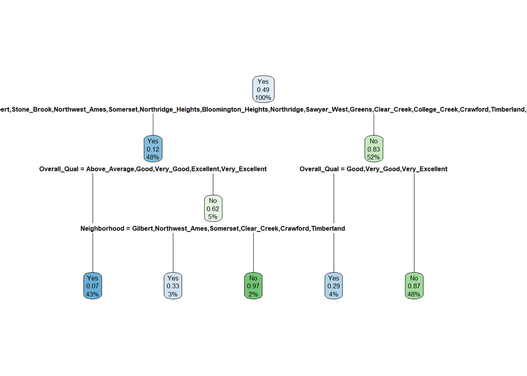

```r
#plot the tree
rpart.plot(tree)
```

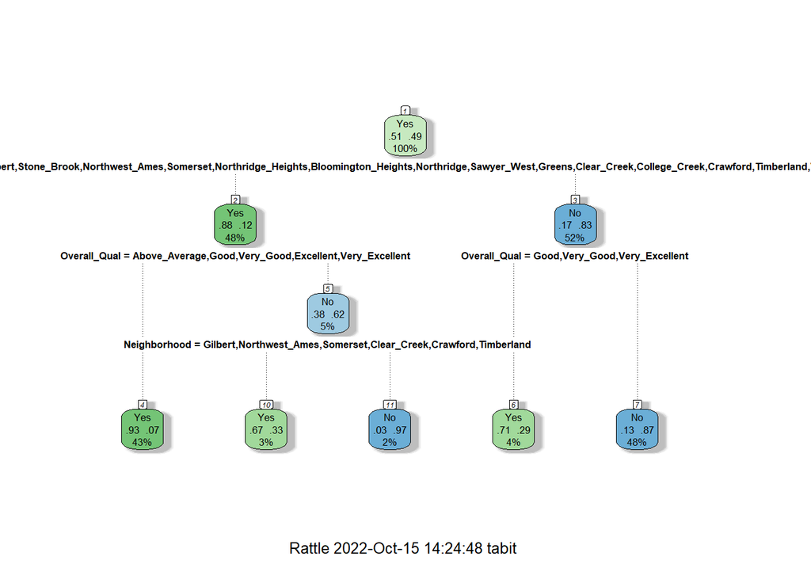

```r
#alternative
fancyRpartPlot(tree)
```

Looking at the “rpart” complexity parameter “cp”.  
A lower Cp value will allow more splits to occur, but at a greater risk of overfitting. A higher Cp value may not provide enough splits. It won’t split if the improvement is not good enough to wort the split.

```r
ames_df_fit$fit$fit$fit$cptable
```

```
##           CP nsplit rel error    xerror       xstd
## 1 0.69872702      0 1.0000000 1.0381895 0.02680266
## 2 0.03253182      1 0.3012730 0.3111740 0.01930673
## 3 0.02263083      2 0.2687412 0.2857143 0.01863637
## 4 0.01697313      3 0.2461103 0.2659123 0.01808058
## 5 0.01000000      4 0.2291372 0.2432815 0.01740451
```

I started with only the “Overall_Qual” variable to start my tree which had 1 level. From my prior tesing using a glm model, this was the strongest predictor.

# Now I will look at XGBoost Models to further develop which predictor variables would be best:

```r
#use_xgboost(Survived ~., train) #comment me out before knitting
```

We pick seeds to make sure that all sets of data get a fair amount of all the data.

```r
set.seed(123)
folds = vfold_cv(train, v = 5)
```

Copy and paste the model from the use_xgboost function. Modify a few elements. We’ll let R tune the parameters by looking at 25 plausible combinations of parameters.

```r
# Commented out because there s a saved model below named : "final_xgb_fit"
#start_time = Sys.time() #for timing

#xgboost_recipe <-
#  recipe(formula = Above_Median ~ ., data = train) %>%
#  #step_novel(all_nominal(), -all_outcomes()) %>%
#  step_dummy(all_nominal(), -all_outcomes(), one_hot = TRUE) %>%
#  step_zv(all_predictors())

#xgboost_spec <-
#  boost_tree(trees = tune(), min_n = tune(), tree_depth = tune(), learn_rate = tune(),
#    loss_reduction = tune(), sample_size = tune()) %>%
#  set_mode("classification") %>%
#  set_engine("xgboost")

#xgboost_workflow <-
#  workflow() %>%
#  add_recipe(xgboost_recipe) %>%
#  add_model(xgboost_spec)

#set.seed(77680)
#xgboost_tune <-
#  tune_grid(xgboost_workflow, resamples = folds, grid = 25)

#end_time = Sys.time()
#end_time - start_time
```

```r
# Commented out because there s a saved model below named : "final_xgb_fit"
#best_xgb = select_best(xgboost_tune, "accuracy")

#final_xgb = finalize_workflow(
#  xgboost_workflow,
#  best_xgb
#)

#final_xgb
```

```r
# Commented out because there s a saved model below named : "final_xgb_fit"
#fit the finalized workflow to our training data
#final_xgb_fit = fit(final_xgb, train)
```

Saving

```r
#saveRDS(final_xgb_fit,"AMES_xgb_fit.rds")
```

Opening saved XGB Model

```r
final_xgb_fit = readRDS("AMES_xgb_fit.rds")
```

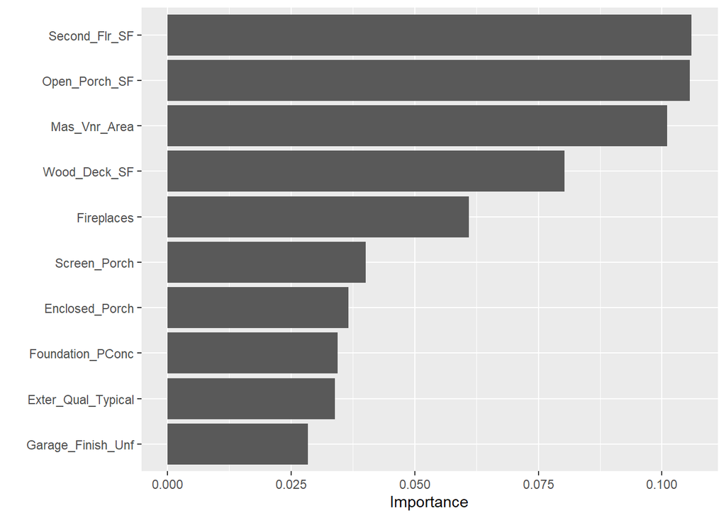

```r
xg_mod = extract_fit_parsnip(final_xgb_fit)
vip(xg_mod$fit)
```

# Random Forest Model

Set-up our folds

```r
set.seed(123)
folds = vfold_cv(train, v = 5)
```

```r
# rf_recipe = ames_df_recipe %>%  #Create basic recipe
#   step_dummy(all_nominal(), -all_outcomes())

#ctrl_grid = control_stack_grid() #necessary for working with tuning grids in the stacks package
#ctrl_res = control_stack_resamples() #necessary for working with the stacks package

# rf_model = rand_forest(mtry = tune(), min_n = tune(), trees = 100) %>% #add tuning of mtry and min_n parameters
#   set_engine("ranger", importance = "permutation") %>% #added importance metric
#   set_mode("classification")

# rf_wflow =
#   workflow() %>%
#   add_model(rf_model) %>%
#   add_recipe(rf_recipe)

# set.seed(123)
# rf_res = tune_grid(
#   rf_wflow,
#   resamples = folds,
#   grid = 200,
#   control = ctrl_grid
#)
```

```r
#saveRDS(rf_res,"rf_res.rds")
```

```r
rf_res = readRDS("rf_res.rds")
```

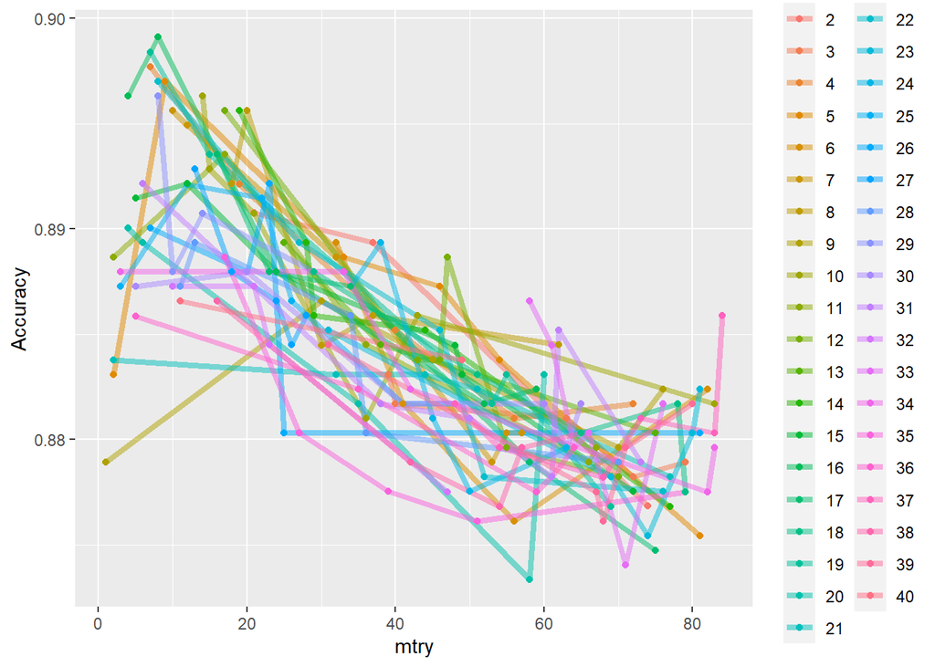

```r
rf_res %>%
  collect_metrics() %>%
  filter(.metric == "accuracy") %>%
  mutate(min_n = factor(min_n)) %>%
  ggplot(aes(mtry, mean, color = min_n)) +
  geom_line(alpha = 0.5, size = 1.5) +
  geom_point() +
  labs(y = "Accuracy")
```

As min (the colors) gets bigger, the accuracy gets worse. mtry gets to maximize around 8. Towards the right gets a rapidly decline in accuracy.

# CONCLUSION

The four models did not have agreement which variables were strong predictors of a house being “Above_Median” price. We saw “Overall_Qual” start strong only to be replaced by “Neighborhood” in our second model. The third model tossed both of these aside and said that “Second_Flr_SF” and “Open_Porch_SF” mattered more. Overall, I have to say that all of these together would probably make a pretty good model.